# BUA 455 Lecture 12 - Parallel Lines Models

Penelope Pooler Eisenbies

2023-02-27

### Getting Started with Markdown

- Download Zipped R project
- Open Zipped folder and copy internal folder (R Project) to a BUA 345 folder on your computer NOT IN DOWLOADS
- Click on .Rproj file to open project
- Click on `code_data_output` file to open it.
- Click on `BUA_345_Lecture_12.Rmd` to open it.
- Run Setup Chunk.

### Setup

- The setup chunk shows the packages needed for this demo.
- R will install specified packages if needed (only required once after R is installed)
- R will load specified packaged (required every time you start a new R session)
- The first time you run this code, R will install these packages which will be slow.
- **If you get warnings, that’s okay.**
- If you get **error messages**, I (or TA), can help you.

### Setup Chunk for Lecture 12

```r
# this line specifies options for default options for all R Chunks
knitr::opts_chunk$set(echo=T, highlight=T)

# suppress scientific notation
options(scipen=100)

# install helper package that loads and installs other packages, if needed
if (!require("pacman")) install.packages("pacman", repos = "http://lib.stat.cmu.edu/R/CRAN/")
# install and load required packages
pacman::p_load(pacman,tidyverse, magrittr, olsrr, gridExtra, ggiraphExtra)

# verify packages
p_loaded()
```

```
##  [1] "ggiraphExtra" "gridExtra"    "olsrr"        "magrittr"     "forcats"
##  [6] "stringr"      "dplyr"        "purrr"        "readr"        "tidyr"
## [11] "tibble"       "ggplot2"      "tidyverse"    "pacman"
```

**NOTES:

- ** Don’t worry about `xaringanthemer` package (required for my slides but not for your code).
- New Package: `ggiraphExtra`

### Review Question - Import data

- Recall The Tennessee Real Estate data:

```r
# import and examine data
tn_houses <- read_csv("TN_houses.csv", show_col_types = F) |>
  glimpse(width=75)
```

```
## Rows: 2,430
## Columns: 7
## $ Bedrooms   <dbl> 4, 3, 3, 5, 4, 4, 4, 3, 4, 4, 4, 3, 3, 4, 3, 4, 5, 4, …
## $ Bathrooms  <dbl> 4.5, 3.0, 4.5, 5.0, 4.0, 3.0, 2.0, 2.0, 3.5, 3.5, 3.0,…
## $ Price      <dbl> 1365000, 300000, 566920, 650000, 456500, 380500, 31815…
## $ Year_built <dbl> 2006, 1987, 1968, 1977, 1974, 1987, 1978, 1976, 1966, …
## $ Address    <chr> "5442  GRANNY WHITE PIKE", "5608  HEARTHSTONE LN", "17…
## $ City       <chr> "BRENTWOOD", "BRENTWOOD", "BRENTWOOD", "BRENTWOOD", "B…
## $ State      <chr> "TN", "TN", "TN", "TN", "TN", "TN", "TN", "TN", "TN", …
```

### Review Question - Natural Log transformation

- We will build an MLR model was using the natural log of Price (ln_Price)
- This transformation is needed because Price is **RIGHT-SKEWED**.
- Review of how to create this transformation

```r
# create new variable in tn_houses dataset
# ln_price = the natural log of price
tn_houses <- tn_houses |>
  mutate(ln_price = log(Price)) |>
  glimpse( width=75)
```

```
## Rows: 2,430
## Columns: 8
## $ Bedrooms   <dbl> 4, 3, 3, 5, 4, 4, 4, 3, 4, 4, 4, 3, 3, 4, 3, 4, 5, 4, …
## $ Bathrooms  <dbl> 4.5, 3.0, 4.5, 5.0, 4.0, 3.0, 2.0, 2.0, 3.5, 3.5, 3.0,…
## $ Price      <dbl> 1365000, 300000, 566920, 650000, 456500, 380500, 31815…
## $ Year_built <dbl> 2006, 1987, 1968, 1977, 1974, 1987, 1978, 1976, 1966, …
## $ Address    <chr> "5442  GRANNY WHITE PIKE", "5608  HEARTHSTONE LN", "17…
## $ City       <chr> "BRENTWOOD", "BRENTWOOD", "BRENTWOOD", "BRENTWOOD", "B…
## $ State      <chr> "TN", "TN", "TN", "TN", "TN", "TN", "TN", "TN", "TN", …
## $ ln_price   <dbl> 14.12666, 12.61154, 13.24797, 13.38473, 13.03134, 12.8…
```

### Review Question - Examination Variable Distrbutions

- Histogram of `Price` (`hist_price`), shows distribution of raw data is right-skewed with high outliers.
- Histogram of `ln_price` (`hist_ln_price`) shows distribution of ln transformed data is symmetric and normally distributed.

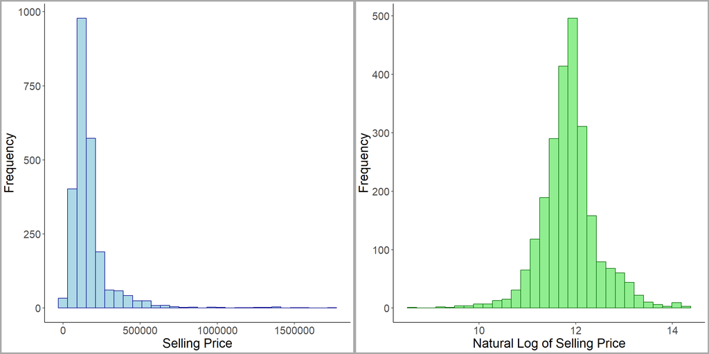

```r
# histogram of original price data
hist_Price <- tn_houses |>
  ggplot() +
  geom_histogram(aes(x=Price), color="darkblue", fill="lightblue") +
  labs(x="Selling Price", y="Frequency") +
  theme_classic() +
  theme(axis.title = element_text(size=18),
        axis.text = element_text(size=15),
        plot.background = element_rect(colour = "darkgrey", fill=NA, size=2))
# histogram of ln_price
hist_ln_price <- tn_houses |>
  ggplot() +
  geom_histogram(aes(x=ln_price), color="darkgreen", fill="lightgreen") +
  labs(x="Natural Log of Selling Price", y="Frequency") +
  theme_classic()+
  theme(axis.title = element_text(size=18),
        axis.text = element_text(size=15),
        plot.background = element_rect(colour = "darkgrey", fill=NA, size=2))

grid.arrange(hist_Price, hist_ln_price, ncol=2)
```

### Review Question - Regression model using `ln_price`

```r
# saves model and prints it to screen because it is enclosed in parentheses
(tn_houses_mlr <- ols_regress(ln_price ~ Bedrooms + Bathrooms, data=tn_houses))
```

```
##                         Model Summary
## -------------------------------------------------------------
## R                       0.558       RMSE               0.489
## R-Squared               0.312       Coef. Var          4.121
## Adj. R-Squared          0.311       MSE                0.239
## Pred R-Squared          0.309       MAE                0.347
## -------------------------------------------------------------
##  RMSE: Root Mean Square Error
##  MSE: Mean Square Error
##  MAE: Mean Absolute Error
##
##                                 ANOVA
## ----------------------------------------------------------------------
##                Sum of
##               Squares          DF    Mean Square       F         Sig.
## ----------------------------------------------------------------------
## Regression    262.637           2        131.319    549.068    0.0000
## Residual      580.457        2427          0.239
## Total         843.094        2429
## ----------------------------------------------------------------------
##
##                                    Parameter Estimates
## -----------------------------------------------------------------------------------------
##       model      Beta    Std. Error    Std. Beta       t        Sig      lower     upper
## -----------------------------------------------------------------------------------------
## (Intercept)    10.972         0.042                 261.401    0.000    10.890    11.055
##    Bedrooms     0.056         0.016        0.071      3.476    0.001     0.024     0.087
##   Bathrooms     0.375         0.015        0.515     25.119    0.000     0.346     0.405
## -----------------------------------------------------------------------------------------
```

### Lecture 12 In-class Exercises - Back-transforming Model Estimates

#### **Question 1 (L12) - Session ID: bua345s23**

**Based on the model output, What is the estimated price of a house with 4 bedrooms and 3 bathrooms (rounded to closest $1000)?**

```r
# incomplete model equation
# fill in intercept and values from question
# (y_est <- ___ + 0.056*4 + 0.375*3)

# back-transform y_est using exp function
# (est_dollars <- exp(y_est))

# round to 1000
# round(est_dollars,-3)
```

NOTE: All 3 steps above could be done with one line but it is helpful to break it down when learning.

### Data Examples - R Star Wars Dataset

- Dataset of characters from Star Wars franchise

```r
?starwars # run this line to see help file documentation
```

```r
my_starwars <- starwars           # save R starwars dataset to Global Environment
my_starwars |> glimpse(width=75)  # examine data
```

```
## Rows: 87
## Columns: 14
## $ name       <chr> "Luke Skywalker", "C-3PO", "R2-D2", "Darth Vader", "Le…
## $ height     <int> 172, 167, 96, 202, 150, 178, 165, 97, 183, 182, 188, 1…
## $ mass       <dbl> 77.0, 75.0, 32.0, 136.0, 49.0, 120.0, 75.0, 32.0, 84.0…
## $ hair_color <chr> "blond", NA, NA, "none", "brown", "brown, grey", "brow…
## $ skin_color <chr> "fair", "gold", "white, blue", "white", "light", "ligh…
## $ eye_color  <chr> "blue", "yellow", "red", "yellow", "brown", "blue", "b…
## $ birth_year <dbl> 19.0, 112.0, 33.0, 41.9, 19.0, 52.0, 47.0, NA, 24.0, 5…
## $ sex        <chr> "male", "none", "none", "male", "female", "male", "fem…
## $ gender     <chr> "masculine", "masculine", "masculine", "masculine", "f…
## $ homeworld  <chr> "Tatooine", "Tatooine", "Naboo", "Tatooine", "Alderaan…
## $ species    <chr> "Human", "Droid", "Droid", "Human", "Human", "Human", …
## $ films      <list> <"The Empire Strikes Back", "Revenge of the Sith", "R…
## $ vehicles   <list> <"Snowspeeder", "Imperial Speeder Bike">, <>, <>, <>,…
## $ starships  <list> <"X-wing", "Imperial shuttle">, <>, <>, "TIE Advanced…
```

### Examining Data

- A good way to examine categorical data variables is to examine how many observations are in each category.
- For example, we can examine the Star Wars character data by species and gender
- Too many species…

```r
# summarizing starwars character data by species and gender
my_starwars |> select(species, gender) |> table()
```

```
##                 gender
## species          feminine masculine
##   Aleena                0         1
##   Besalisk              0         1
##   Cerean                0         1
##   Chagrian              0         1
##   Clawdite              1         0
##   Droid                 1         5
##   Dug                   0         1
##   Ewok                  0         1
##   Geonosian             0         1
##   Gungan                0         3
##   Human                 9        26
##   Hutt                  0         1
##   Iktotchi              0         1
##   Kaleesh               0         1
##   Kaminoan              1         1
##   Kel Dor               0         1
##   Mirialan              2         0
##   Mon Calamari          0         1
##   Muun                  0         1
##   Nautolan              0         1
##   Neimodian             0         1
##   Pau'an                0         1
##   Quermian              0         1
##   Rodian                0         1
##   Skakoan               0         1
##   Sullustan             0         1
##   Tholothian            1         0
##   Togruta               1         0
##   Toong                 0         1
##   Toydarian             0         1
##   Trandoshan            0         1
##   Twi'lek               1         1
##   Vulptereen            0         1
##   Wookiee               0         2
##   Xexto                 0         1
##   Yoda's species        0         1
##   Zabrak                0         2
```

### Lecture 12 In-class Exercises

#### **Question 2 (L12) - Session ID: bua345s23**

**Is species a nominal or ordinal variable?**

### Star wars Example - Examining categorical Data

- Since `Human` is the most common species, we can filter the data to look at those characters only.
- Then we can examine prevalence of each gender and eye color among human characters.

```r
my_starwars |> filter(species=="Human") |> # filter to humans only
  select(gender, eye_color) |>             # examine genders and eye colors
  table()
```

```
##            eye_color
## gender      blue blue-gray brown dark hazel yellow
##   feminine     3         0     5    0     1      0
##   masculine    9         1    12    1     1      2
```

### Lecture 12 In-class Exercises

#### **Question 3 (L12) - Session ID: bua345s23**

- **Which R command is used to summarize the number of observations in each gender x eye_color combination?**

NOTE: This useful command will also be used in HW 6.

### Data Examples - GT cars dataset

- Deluxe automobiles from the 2014-2017 period

```r
?gt::gtcars # run this line to see help file documentation
```

```r
gt_cars <- read_csv("gt_cars.csv", show_col_types = F) |> # import data
  glimpse(width=75)
```

```
## Rows: 47
## Columns: 15
## $ mfr         <chr> "Ford", "Ferrari", "Ferrari", "Ferrari", "Ferrari", "…
## $ model       <chr> "GT", "458 Speciale", "458 Spider", "458 Italia", "48…
## $ year        <dbl> 2017, 2015, 2015, 2014, 2016, 2015, 2017, 2015, 2015,…
## $ trim        <chr> "Base Coupe", "Base Coupe", "Base", "Base Coupe", "Ba…
## $ bdy_style   <chr> "coupe", "coupe", "convertible", "coupe", "coupe", "c…
## $ hp          <dbl> 647, 597, 562, 562, 661, 553, 680, 652, 731, 949, 573…
## $ hp_rpm      <dbl> 6250, 9000, 9000, 9000, 8000, 7500, 8250, 8000, 8250,…
## $ trq         <dbl> 550, 398, 398, 398, 561, 557, 514, 504, 509, 664, 476…
## $ trq_rpm     <dbl> 5900, 6000, 6000, 6000, 3000, 4750, 5750, 6000, 6000,…
## $ mpg_c       <dbl> 11, 13, 13, 13, 15, 16, 12, 11, 11, 12, 21, 16, 11, 1…
## $ mpg_h       <dbl> 18, 17, 17, 17, 22, 23, 17, 16, 16, 16, 22, 22, 18, 2…
## $ drivetrain  <chr> "rwd", "rwd", "rwd", "rwd", "rwd", "rwd", "awd", "awd…
## $ trsmn       <chr> "7a", "7a", "7a", "7a", "7a", "7a", "7a", "7a", "7a",…
## $ ctry_origin <chr> "United States", "Italy", "Italy", "Italy", "Italy", …
## $ msrp        <dbl> 447000, 291744, 263553, 233509, 245400, 198973, 29800…
```

### GT Cars Example - Examining categorical Data

```r
gt_cars |> select(bdy_style, year) |> table()
```

```
##              year
## bdy_style     2014 2015 2016 2017
##   convertible    0    2    2    1
##   coupe          2    7   16    7
##   hatchback      0    0    2    0
##   sedan          0    0    7    1
```

### Lecture 12 In-class Exercises

#### **Question 4 (L12) - Session ID: bua345s23**

**Which variable in gt_cars, body style (`bdy_style`) or `year`** could** be treated as ordinal?**

### Data Example - Celebrity Salaries Data

- Many (not all) celebrities see a decrease in their annual income as they age.
- There is a negative relationship between wages and ages.
- Is this relationship the same for males a females?

```r
# import celebrity data
celeb <- read_csv("celeb.csv", show_col_types = F) |>
  glimpse(width=75)
```

```
## Rows: 16
## Columns: 4
## $ Celebrity <chr> "Taylor Swift", "Lady Gaga", "Gisele B\xfcndchen", "Bey…
## $ Earnings  <dbl> 67, 59, 54, 54, 51, 28, 24, 70, 81, 70, 77, 68, 64, 56,…
## $ Age       <dbl> 27, 31, 32, 35, 36, 44, 47, 29, 29, 32, 32, 35, 36, 39,…
## $ Gender    <chr> "Female", "Female", "Female", "Female", "Female", "Fema…
```

### Celebrity Salaries Data - Examining categories and Correlations

```r
celeb |> select(Gender) |> table()  # examine counts for each category
```

```
## Gender
## Female   Male
##      8      8
```

```r
celeb |> select(Earnings, Age) |> cor() |> round(2) # examine correlation between earnings and age
```

```
##          Earnings   Age
## Earnings     1.00 -0.86
## Age         -0.86  1.00
```

### Celebrity Salaries Data - Examining Model Options

#### Model Option 1: SLR

- This model assumes no difference between males and females.
- In this case we use Base R command for regression, `lm`.
- Model created with `lm` can be used to create an interactive plot.

```r
# slr model created using lm
celeb_slr <- lm(Earnings ~ Age, data=celeb)

# create and save interactive plot
(int_clb_slr <- ggPredict(celeb_slr, interactive=T))
```

[interactive chart not shown]

### Celebrity Salaries Data - Examining Model Options

#### Model Option 2: Categorical Regression Model

- The SLR mode is okay, but we can probably do better.
- It is logical to suspect there is a difference between males and females in terms of earnings
- We add `Gender` to the model to test this:

```r
# mlr model created using lm
celeb_cat_lm <- lm(Earnings ~ Age + Gender, data=celeb)

# create and save interactive plot
(int_clb_mlr <- ggPredict(celeb_cat_lm, interactive=T))
```

[interactive chart not shown]

### Celebrity Salaries Data - MLR Model Output

- We can see the model equation (poorly formatted) for each gender, in the plot.
- We can also get these equations from the model output, but it requires a little work.
- Examine the model output:

```r
# formatted regression output
# model is saved and printed to screen
(celeb_cat_ols<- ols_regress(Earnings ~ Age + Gender, data=celeb))
```

```
##                         Model Summary
## -------------------------------------------------------------
## R                       0.987       RMSE               2.823
## R-Squared               0.975       Coef. Var          4.959
## Adj. R-Squared          0.971       MSE                7.972
## Pred R-Squared          0.962       MAE                2.197
## -------------------------------------------------------------
##  RMSE: Root Mean Square Error
##  MSE: Mean Square Error
##  MAE: Mean Absolute Error
##
##                                 ANOVA
## ---------------------------------------------------------------------
##                 Sum of
##                Squares        DF    Mean Square       F         Sig.
## ---------------------------------------------------------------------
## Regression    4007.300         2       2003.650    251.332    0.0000
## Residual       103.637        13          7.972
## Total         4110.937        15
## ---------------------------------------------------------------------
##
##                                     Parameter Estimates
## --------------------------------------------------------------------------------------------
##       model       Beta    Std. Error    Std. Beta       t        Sig       lower      upper
## --------------------------------------------------------------------------------------------
## (Intercept)    134.112         4.141                  32.384    0.000    125.165    143.059
##         Age     -2.370         0.114       -0.918    -20.710    0.000     -2.617     -2.123
##  GenderMale     15.383         1.420        0.480     10.830    0.000     12.315     18.452
## --------------------------------------------------------------------------------------------
```

### Lecture 12 In-class Exercises

#### **Question 5 (L12) - Session ID: bua345s23**

**Based on our categorical regression model, is the difference between male and female earnings (approx. 15 $M), statistically significant?**

HINT: Look at the p-value for the **`GenderMale`** term in the model to answer this question.

### Data Example - House Remodeling Data

- What is the effect of remodeling on house selling price?

```r
# import house remodeling data
house_remodel <- read_csv("house_remodel.csv", show_col_types = F) |>
  glimpse(width=75)
```

```
## Rows: 57
## Columns: 3
## $ Price       <dbl> 554000, 484000, 391000, 354000, 410000, 349000, 40900…
## $ Square_Feet <dbl> 2702, 2378, 1846, 1820, 1794, 1768, 1752, 1719, 1676,…
## $ Remodeled   <chr> "No", "No", "No", "No", "No", "No", "No", "No", "No",…
```

### House Remodeling Data - Examine Categories and Correlations

- What is the effect of remodeling on house selling price?

```r
# examine number of obs in each category
house_remodel |> select(Remodeled) |> table()
```

```
## Remodeled
##  No Yes
##  29  28
```

```r
# correlation between price and square feet
house_remodel |> select(Price, Square_Feet) |> cor() |> round(2)
```

```
##             Price Square_Feet
## Price        1.00        0.75
## Square_Feet  0.75        1.00
```

### House Remodeling Data - Examining Model Options

#### Model Option 1: SLR

- SLR model assumes no difference due to remodeling
- Again, we use Base R command for regression, `lm`
- Model created with `lm` can be used to create an interactive plot.

```r
# slr model created using lm
rem_slr <- lm(Price ~ Square_Feet, data=house_remodel)

# create and save interactive plot
(int_rem_slr <- ggPredict(rem_slr, interactive=T))
```

[interactive chart not shown]

### House Remodeling Data - Examining Model Options

#### Model Option 2: Categorical Regression Model

- SLR mode is okay, but there is likely to be a difference between `Remodeled` and un-`Remodeled` houses.
- To test for that difference we add the categorical variable `Remodeled` to the model:

```r
# mlr model created using lm
rem_cat_lm <- lm(Price ~ Square_Feet + Remodeled, data=house_remodel)

# create and save interactive plot
(int_rem_mlr <- ggPredict(rem_cat_lm, interactive=T))
```

[interactive chart not shown]

### House Remodel dataa - MLR Model Output

- We can see the model equation (poorly formatted) for each category, in the plot.
- We can also get these equations from the model output, but it requires a little work.
- Examine the model output:

```r
# formatted regression output
# model is saved and printed to screen
(house_rem_ols<- ols_regress(Price ~ Square_Feet + Remodeled, data=house_remodel))
```

```
##                             Model Summary
## ----------------------------------------------------------------------
## R                       0.924       RMSE                    32958.534
## R-Squared               0.854       Coef. Var                   8.223
## Adj. R-Squared          0.848       MSE                1086264973.997
## Pred R-Squared          0.836       MAE                     28012.693
## ----------------------------------------------------------------------
##  RMSE: Root Mean Square Error
##  MSE: Mean Square Error
##  MAE: Mean Absolute Error
##
##                                       ANOVA
## ----------------------------------------------------------------------------------
##                         Sum of
##                        Squares        DF         Mean Square       F         Sig.
## ----------------------------------------------------------------------------------
## Regression    341892090457.686         2    170946045228.843     157.37    0.0000
## Residual       58658308595.823        54      1086264973.997
## Total         400550399053.509        56
## ----------------------------------------------------------------------------------
##
##                                          Parameter Estimates
## -----------------------------------------------------------------------------------------------------
##        model          Beta    Std. Error    Std. Beta      t        Sig          lower         upper
## -----------------------------------------------------------------------------------------------------
##  (Intercept)    137549.093     17620.447                  7.806    0.000    102222.224    172875.963
##  Square_Feet       137.879        10.836        0.670    12.725    0.000       116.155       159.602
## RemodeledYes     90917.216      8834.268        0.542    10.291    0.000     73205.575    108628.858
## -----------------------------------------------------------------------------------------------------
```

### Getting Model Equations from Regression Output

- By default R chooses baseline categories alphabetically
  - `No` is before `Yes` so un-`Remodeled` houses are the baseline
  - un-Remodeled SLR Model: `Est. Price = 137549.093 + 137.879 * Square_Feet`
  - Remodeled SLR Model:
    - `Est. Price = 137549.093 + 137.879 * Square_Feet + 90917.216`
    - `Est. Price = 137549.093 + 90917.216 + 137.879 * Square_Feet`
    - `Est. Price = _____ + 137.879 * Square_Feet`

### Lecture 12 In-class Exercises

#### **Question 6 (L12) - Session ID: bua345s23**

The difference between the intercepts for `Remodeled` and un-`Remodeled` houses is shown in the model output.

- Difference in intercepts is labeled with name of categorical variable and category
- Difference (Increase) for remodeling is labeled **`RemodeledYes`** and equals **`90917.216`**

**What is the** intercept** for the prices of ‘Remodeled’ houses in the Categorical Regression model (Round to closest thousand ($K).**

#### **Question 7 (L12) - Session ID: bua345s23**

**Based on our categorical regression model, is the difference in selling price between remodeled (Remodeled = `Yes`) and un-remodeled (Remodeled = `No`) homes statistically significant?**

### **Key Points from Today**

- Categorical Parallel Lines Model
  - Separate SLR model for each category.
  - Modeling categories simultaneously with one mode is
    - more efficient
    - more accurate
- Next Similar Model BUT each category has a different slope
- HW 6 is posted (Due 3/6)
- First set of data is **almost** identical to `house_remodel` data.

You may submit an ‘Engagement Question’ about each lecture until midnight on the day of the lecture. **A minimum of four submissions are required during the semester.**